# The bkmrhat package: diagnostics and multi-chain inference in Bayesian kernel machine regression

### Example 5: Parallel posterior summaries as diagnostics

`bkmrhat` also has ported versions of the native posterior summarization functions to compare how these summaries vary across parallel chains. Note that these should serve as diagnostics, and final posterior inference should be done on the combined chain. The easiest of these functions to demonstrate is the `OverallRiskSummaries_parallel` function, which simply runs `OverallRiskSummaries` (from the `bkmr` package) on each chain and combines the results. Notably, this function fixes the y-axis at zero for the median, so it under-represents overall predictive variation across chains, but captures variation in effect estimates across the chains. Ideally, that variation is negligible - e.g. if you see differences between chains that would result in different interpretations, you should re-fit the model with more iterations. In this example, the results are reasonably consistent across chains, but one might want to run more iterations if, say, the differences seen across the upper error bounds are of such a magnitude as to be practically meaningful.

```r
set.seed(111)
system.time(kmfitbma.list <- suppressWarnings(kmbayes_parallel(nchains=4, y = y, Z = Z, X = X, iter = 1000, verbose = FALSE, varsel = TRUE)))
```

```
## Chain 1
```

```
## Iteration: 100 (10% completed; 0.04437 secs elapsed)
```

```
## Iteration: 200 (20% completed; 0.08926 secs elapsed)
```

```
## Iteration: 300 (30% completed; 0.13463 secs elapsed)
```

```
## Iteration: 400 (40% completed; 0.18461 secs elapsed)
```

```
## Iteration: 500 (50% completed; 0.22756 secs elapsed)
```

```
## Iteration: 600 (60% completed; 0.27209 secs elapsed)
```

```
## Iteration: 700 (70% completed; 0.42183 secs elapsed)
```

```
## Iteration: 800 (80% completed; 0.47734 secs elapsed)
```

```
## Iteration: 900 (90% completed; 0.52534 secs elapsed)
```

```
## Iteration: 1000 (100% completed; 0.57117 secs elapsed)
```

```
## Chain 2
```

```
## Iteration: 100 (10% completed; 0.0453 secs elapsed)
```

```
## Iteration: 200 (20% completed; 0.09534 secs elapsed)
```

```
## Iteration: 300 (30% completed; 0.14516 secs elapsed)
```

```
## Iteration: 400 (40% completed; 0.19311 secs elapsed)
```

```
## Iteration: 500 (50% completed; 0.23682 secs elapsed)
```

```
## Iteration: 600 (60% completed; 0.40315 secs elapsed)
```

```
## Iteration: 700 (70% completed; 0.44757 secs elapsed)
```

```
## Iteration: 800 (80% completed; 0.49265 secs elapsed)
```

```
## Iteration: 900 (90% completed; 0.54188 secs elapsed)
```

```
## Iteration: 1000 (100% completed; 0.58522 secs elapsed)
```

```
## Chain 3
```

```
## Iteration: 100 (10% completed; 0.04957 secs elapsed)
```

```
## Iteration: 200 (20% completed; 0.09726 secs elapsed)
```

```
## Iteration: 300 (30% completed; 0.14525 secs elapsed)
```

```
## Iteration: 400 (40% completed; 0.32493 secs elapsed)
```

```
## Iteration: 500 (50% completed; 0.36995 secs elapsed)
```

```
## Iteration: 600 (60% completed; 0.41537 secs elapsed)
```

```
## Iteration: 700 (70% completed; 0.46255 secs elapsed)
```

```
## Iteration: 800 (80% completed; 0.50596 secs elapsed)
```

```
## Iteration: 900 (90% completed; 0.54883 secs elapsed)
```

```
## Iteration: 1000 (100% completed; 0.59305 secs elapsed)
```

```
## Chain 4
```

```
## Iteration: 100 (10% completed; 0.17464 secs elapsed)
```

```
## Iteration: 200 (20% completed; 0.22162 secs elapsed)
```

```
## Iteration: 300 (30% completed; 0.26513 secs elapsed)
```

```
## Iteration: 400 (40% completed; 0.3083 secs elapsed)
```

```
## Iteration: 500 (50% completed; 0.4671 secs elapsed)
```

```
## Iteration: 600 (60% completed; 0.51094 secs elapsed)
```

```
## Iteration: 700 (70% completed; 0.55433 secs elapsed)
```

```
## Iteration: 800 (80% completed; 0.59765 secs elapsed)
```

```
## Iteration: 900 (90% completed; 0.65502 secs elapsed)
```

```
## Iteration: 1000 (100% completed; 0.69891 secs elapsed)
```

```
##    user  system elapsed
##   0.349   0.051   1.092
```

```r
meandifference_par = OverallRiskSummaries_parallel(kmfitbma.list, y = y, Z = Z, X = X ,qs = seq(0.25, 0.75, by = 0.05), q.fixed = 0.5, method = "exact")
```

```
## Chain 1
## Chain 2
## Chain 3
## Chain 4
```

```r
head(meandifference_par)
```

```
##   quantile        est         sd chain
## 1     0.25 -0.6191983 0.12051657     1
## 2     0.30 -0.5019924 0.09747662     1
## 3     0.35 -0.3067245 0.08058220     1
## 4     0.40 -0.2311694 0.04357326     1
## 5     0.45 -0.1454666 0.02463054     1
## 6     0.50  0.0000000 0.00000000     1
```

```r
nchains = length(unique(meandifference_par$chain))

with(meandifference_par, {
  plot.new()
  plot.window(ylim=c(min(est - 1.96*sd), max(est + 1.96*sd)),
              xlim=c(min(quantile), max(quantile)),
       ylab= "Mean difference", xlab = "Joint quantile")
  for(cch in seq_len(nchains)){
    width = diff(quantile)[1]
    jit = runif(1, -width/5, width/5)
   points(jit+quantile[chain==cch], est[chain==cch], pch=19, col=cch)
   segments(x0=jit+quantile[chain==cch], x1=jit+quantile[chain==cch], y0 = est[chain==cch] - 1.96*sd[chain==cch], y1 = est[chain==cch] + 1.96*sd[chain==cch], col=cch)
  }
  abline(h=0)
  axis(1)
  axis(2)
  box(bty='l')
  legend("bottom", col=1:nchains, pch=19, lty=1, legend=paste("chain", 1:nchains), bty="n")
})

regfuns_par = PredictorResponseUnivar_parallel(kmfitbma.list, y = y, Z = Z, X = X ,qs = seq(0.25, 0.75, by = 0.05), q.fixed = 0.5, method = "exact")
```

```
## Chain 1
## Chain 2
## Chain 3
## Chain 4
```

```r
head(regfuns_par)
```

```
##   variable         z       est        se chain
## 1       z1 -2.186199 -1.435648 0.5915233     1
## 2       z1 -2.082261 -1.379339 0.5677579     1
## 3       z1 -1.978323 -1.321802 0.5442158     1
## 4       z1 -1.874385 -1.263092 0.5208719     1
## 5       z1 -1.770446 -1.203272 0.4977049     1
## 6       z1 -1.666508 -1.142409 0.4746991     1
```

[figure not shown]

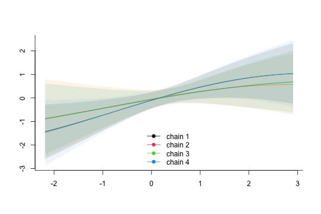

```r
nchains = length(unique(meandifference_par$chain))

# single variable
with(regfuns_par[regfuns_par$variable=="z1",], {
  plot.new()
  plot.window(ylim=c(min(est - 1.96*se), max(est + 1.96*se)),
              xlim=c(min(z), max(z)),
       ylab= "Predicted Y", xlab = "Z")
  pc = c("#000000", "#E69F00", "#56B4E9", "#009E73", "#F0E442", "#0072B2", "#D55E00", "#CC79A7", "#999999")
  pc2 = c("#0000001A", "#E69F001A", "#56B4E91A", "#009E731A", "#F0E4421A", "#0072B21A", "#D55E001A", "#CC79A71A", "#9999991A")
  for(cch in seq_len(nchains)){
   ribbonX = c(z[chain==cch], rev(z[chain==cch]))
   ribbonY = c(est[chain==cch] + 1.96*se[chain==cch], rev(est[chain==cch] - 1.96*se[chain==cch]))
   polygon(x=ribbonX, y = ribbonY, col=pc2[cch], border=NA)
   lines(z[chain==cch], est[chain==cch], pch=19, col=pc[cch])
  }
  axis(1)
  axis(2)
  box(bty='l')
  legend("bottom", col=1:nchains, pch=19, lty=1, legend=paste("chain", 1:nchains), bty="n")
})
```

### Example 6: Continuing a fit

Sometimes you just need to run more samples in an existing chain. For example, you run a bkmr fit for 3 days, only to find you don’t have enough samples. A “continued” fit just means that you can start off at the last iteration you were at and just keep building on an existing set of results by lengthening the Markov chain. Unfortunately, due to how the `kmbayes` function accepts starting values (for the official install version), you can’t quite do this *exactly* in many cases (The function will relay a message and possible solutions, if any. `bkmr` package authors are aware of this issue). The `kmbayes_continue` function continues a `bkmr` fit as well as the `bkmr` package will allow. The `r` parameters from the fit must all be initialized at the same value, so `kmbayes_continue` starts a new MCMC fit at the final values of all parameters from the prior bkmr fit, but sets all of the `r` parameters to the mean at the last iteration from the previous fit. Additionally, if `h.hat` parameters are estimated, these are fixed to be above zero to meet similar constraints, either by fixing them at their posterior mean or setting to a small positive value. One should inspect trace plots to see whether this will cause issues (e.g. if the traceplots demonstrate different patterns in the samples before and after the continuation). Here’s an example with a quick check of diagnostics of the first part of the chain, and the combined chain (which could be used for inference or extended again, if necessary). We caution users that this function creates 2 distinct, if very similar Markov chains, and to use appropriate caution if traceplots differ before and after each continuation. Nonetheless, in many cases one can act as though all samples are from the same Markov chain.

Note that if you install the developmental version of the `bkmr` package you can continue fits from exactly where they left off, so you get a true, single Markov chain. You can install that via the commented code below

```r
# install dev version of bkmr to allow true continued fits.
#install.packages("devtools")
#devtools::install_github("jenfb/bkmr")

set.seed(111)
# run 100 initial iterations for a model with only 2 exposures
Z2 = Z[,1:2]
kmfitbma.start <- suppressWarnings(kmbayes(y = y, Z = Z2, X = X, iter = 500, verbose = FALSE, varsel = FALSE))
```

```
## Iteration: 50 (10% completed; 0.02397 secs elapsed)
```

```
## Iteration: 100 (20% completed; 0.05547 secs elapsed)
```

```
## Iteration: 150 (30% completed; 0.08043 secs elapsed)
```

```
## Iteration: 200 (40% completed; 0.10795 secs elapsed)
```

```
## Iteration: 250 (50% completed; 0.13285 secs elapsed)
```

```
## Iteration: 300 (60% completed; 0.16364 secs elapsed)
```

```
## Iteration: 350 (70% completed; 0.18805 secs elapsed)
```

```
## Iteration: 400 (80% completed; 0.21684 secs elapsed)
```

```
## Iteration: 450 (90% completed; 0.24108 secs elapsed)
```

```
## Iteration: 500 (100% completed; 0.27007 secs elapsed)
```

```r
kmbayes_diag(kmfitbma.start)
```

```
## Single chain
```

```
## Inference for the input samples (1 chains: each with iter = 500; warmup = 250):
##
##            Q5  Q50  Q95 Mean  SD  Rhat Bulk_ESS Tail_ESS
## beta1     1.9  2.0  2.0  2.0 0.0  1.02      184      238
## beta2     0.0  0.1  0.2  0.1 0.1  1.00      259      197
## lambda    6.4 15.0 33.2 17.0 8.2  1.03       32       38
## r1        0.0  0.0  0.0  0.0 0.0  1.20        5       16
## r2        0.0  0.0  0.1  0.0 0.0  1.01       26       28
## sigsq.eps 0.3  0.4  0.5  0.4 0.1  1.00      195      157
##
## For each parameter, Bulk_ESS and Tail_ESS are crude measures of
## effective sample size for bulk and tail quantities respectively (an ESS > 100
## per chain is considered good), and Rhat is the potential scale reduction
## factor on rank normalized split chains (at convergence, Rhat <= 1.05).
```

```
##                  mean     se_mean         sd        2.5%         25%
## beta1      1.96002469 0.002996717 0.04071499  1.88732666  1.93049212
## beta2      0.09934846 0.005601868 0.09100445 -0.06425935  0.03866907
## lambda    17.03096186 1.480162990 8.16066439  5.99261263 10.62650587
## r1         0.02445179 0.006963033 0.01503557  0.01009566  0.01650405
## r2         0.02931652 0.003839555 0.02294888  0.01050284  0.01300914
## sigsq.eps  0.38177766 0.006062528 0.08483668  0.25337749  0.32965181
##                   50%         75%       97.5% n_eff      Rhat valid          Q5
## beta1      1.96168526  1.98761915  2.04042002   192 1.0174270     1  1.89496869
## beta2      0.09494353  0.15892943  0.26004214   263 0.9979147     1 -0.04566104
## lambda    14.97716478 22.17297877 35.85230190    32 1.0322926     1  6.39370841
## r1         0.02078562  0.03098429  0.04827171    12 1.1969882     1  0.01009566
## r2         0.02369039  0.03766762  0.09155390    38 1.0072685     1  0.01213386
## sigsq.eps  0.36834066  0.42589940  0.61832629   187 0.9989252     1  0.26493273
##                   Q50         Q95    MCSE_Q2.5    MCSE_Q25    MCSE_Q50
## beta1      1.96168526  2.02239974 0.0061439984 0.003896226 0.004052288
## beta2      0.09494353  0.24851228 0.0125216874 0.009226277 0.006555085
## lambda    14.97716478 33.24311222 1.2308679562 0.873763048 1.767460797
## r1         0.02078562  0.04809447 0.0006957382 0.002532962 0.004430201
## r2         0.02369039  0.07473096 0.0011501569 0.001816037 0.004755380
## sigsq.eps  0.36834066  0.53371298 0.0112954790 0.004960890 0.004978161
##              MCSE_Q75  MCSE_Q97.5     MCSE_SD Bulk_ESS Tail_ESS
## beta1     0.001302716 0.010539232 0.002122356      184      238
## beta2     0.008043386 0.008643991 0.003965505      259      197
## lambda    3.451601827 1.237140963 1.056843473       32       38
## r1        0.006131920 0.001462048 0.005269340        5       16
## r2        0.002075801 0.013178244 0.002737455       26       28
## sigsq.eps 0.006630407 0.039435542 0.004293256      195      157
```

```r
# run 2000 additional iterations
moreiterations = kmbayes_continue(kmfitbma.start, iter=2000)
```

```
## Validating control.params...
```

```
## Validating starting.values...
```

```
## Iteration: 201 (10% completed; 0.12364 secs elapsed)
```

```
## Acceptance rates for Metropolis-Hastings algorithm:
##    param  rate
## 1 lambda 0.430
## 2     r1 0.245
## 3     r2 0.235
```

```
## Iteration: 401 (20% completed; 0.24282 secs elapsed)
```

```
## Acceptance rates for Metropolis-Hastings algorithm:
##    param   rate
## 1 lambda 0.4675
## 2     r1 0.1850
## 3     r2 0.2500
```

```
## Iteration: 601 (30% completed; 0.36783 secs elapsed)
```

```
## Acceptance rates for Metropolis-Hastings algorithm:
##    param      rate
## 1 lambda 0.4966667
## 2     r1 0.1633333
## 3     r2 0.2333333
```

```
## Iteration: 801 (40% completed; 0.4825 secs elapsed)
```

```
## Acceptance rates for Metropolis-Hastings algorithm:
##    param    rate
## 1 lambda 0.49625
## 2     r1 0.18500
## 3     r2 0.25250
```

```
## Iteration: 1001 (50% completed; 0.59947 secs elapsed)
```

```
## Acceptance rates for Metropolis-Hastings algorithm:
##    param  rate
## 1 lambda 0.489
## 2     r1 0.192
## 3     r2 0.243
```

```
## Iteration: 1201 (60% completed; 0.72636 secs elapsed)
```

```
## Acceptance rates for Metropolis-Hastings algorithm:
##    param      rate
## 1 lambda 0.4908333
## 2     r1 0.1900000
## 3     r2 0.2416667
```

```
## Iteration: 1401 (70% completed; 0.84681 secs elapsed)
```

```
## Acceptance rates for Metropolis-Hastings algorithm:
##    param      rate
## 1 lambda 0.4921429
## 2     r1 0.1928571
## 3     r2 0.2457143
```

```
## Iteration: 1601 (80% completed; 0.9701 secs elapsed)
```

```
## Acceptance rates for Metropolis-Hastings algorithm:
##    param     rate
## 1 lambda 0.490625
## 2     r1 0.199375
## 3     r2 0.246250
```

```
## Iteration: 1801 (90% completed; 1.08822 secs elapsed)
```

```
## Acceptance rates for Metropolis-Hastings algorithm:
##    param      rate
## 1 lambda 0.4888889
## 2     r1 0.1983333
## 3     r2 0.2516667
```

```
## Iteration: 2001 (100% completed; 1.20897 secs elapsed)
```

```
## Acceptance rates for Metropolis-Hastings algorithm:
##    param   rate
## 1 lambda 0.4940
## 2     r1 0.2005
## 3     r2 0.2485
```

```r
kmbayes_diag(moreiterations)
```

```
## Single chain
```

```
## Inference for the input samples (1 chains: each with iter = 2500; warmup = 1250):
##
##            Q5  Q50  Q95 Mean  SD  Rhat Bulk_ESS Tail_ESS
## beta1     1.9  2.0  2.0  2.0 0.0     1     1226     1188
## beta2     0.0  0.1  0.2  0.1 0.1     1     1342     1153
## lambda    4.8 11.6 27.8 13.5 7.2     1      132      118
## r1        0.0  0.0  0.1  0.0 0.0     1       36       60
## r2        0.0  0.0  0.1  0.0 0.0     1       63       74
## sigsq.eps 0.3  0.4  0.5  0.4 0.1     1      687      907
##
## For each parameter, Bulk_ESS and Tail_ESS are crude measures of
## effective sample size for bulk and tail quantities respectively (an ESS > 100
## per chain is considered good), and Rhat is the potential scale reduction
## factor on rank normalized split chains (at convergence, Rhat <= 1.05).
```

```
##                  mean     se_mean         sd        2.5%        25%         50%
## beta1      1.95902186 0.001313130 0.04611042  1.86406579 1.92824507  1.95995430
## beta2      0.10364082 0.002472674 0.09078254 -0.08028629 0.04483808  0.10217365
## lambda    13.45858048 0.575042840 7.18975272  4.63158214 8.06723496 11.62070182
## r1         0.02558935 0.002505863 0.01684645  0.01051616 0.01389383  0.02000374
## r2         0.03152169 0.002840685 0.02568259  0.01042071 0.01378317  0.02173483
## sigsq.eps  0.39671746 0.003232309 0.08256885  0.26948029 0.33468348  0.38833815
##                   75%       97.5% n_eff     Rhat valid          Q5         Q50
## beta1      1.99013424  2.05059125  1236 1.000076     1  1.88233558  1.95995430
## beta2      0.16648882  0.27919590  1353 1.001507     1 -0.04502216  0.10217365
## lambda    17.07843757 32.36093597   156 1.000211     1  4.81793593 11.62070182
## r1         0.03034907  0.07050527    45 1.004470     1  0.01097881  0.02000374
## r2         0.03773703  0.10918759    80 1.001841     1  0.01069795  0.02173483
## sigsq.eps  0.44446826  0.59030414   650 1.000453     1  0.28159002  0.38833815
##                   Q95    MCSE_Q2.5     MCSE_Q25    MCSE_Q50    MCSE_Q75
## beta1      2.03392196 0.0034878092 0.0018218271 0.001705603 0.001924244
## beta2      0.24728033 0.0063559462 0.0036553685 0.002849542 0.003241571
## lambda    27.83773681 0.2173104821 0.6064432977 0.646607402 0.583887847
## r1         0.06248365 0.0004568228 0.0017076967 0.002442041 0.003929030
## r2         0.07985574 0.0002483599 0.0009401994 0.002913607 0.004161742
## sigsq.eps  0.54458362 0.0028952538 0.0027590593 0.003419585 0.004708623
##            MCSE_Q97.5      MCSE_SD Bulk_ESS Tail_ESS
## beta1     0.004277831 0.0009293335     1226     1188
## beta2     0.009449827 0.0017774270     1342     1153
## lambda    1.708604468 0.4073777680      132      118
## r1        0.005777434 0.0017834748       36       60
## r2        0.011995755 0.0020158792       63       74
## sigsq.eps 0.007480563 0.0023104526      687      907
```

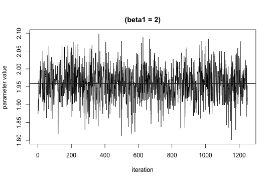

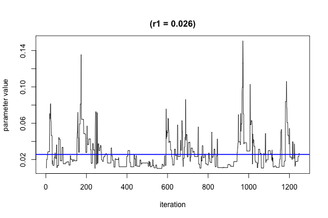

```r
TracePlot(moreiterations, par="beta")
TracePlot(moreiterations, par="r")


# move to sequential processing (end of vignette)
future::plan(strategy = future::sequential)
```

### Acknowledgments

Thanks to Haotian “Howie” Wu for invaluable feedback on early versions of the package.